# Python assignment: Applied Economic Analysis 1

| Name |  | ANR |
| --- | --- | --- |
| Mark Bastiaanse |  | 954140 |

January 31, 2018

## European Corporate Tax Rates and Tax Havens

## Abstract

There is a downwards trend in corporate tax rates going on for the past 15 years. This is known as the 'Race to the bottom'. This may be due to the existence of tax havens, or more intense competition between countries. The LuxLeaks and Panama Papers did not cause a change in tax rate setting.

## Question

Is the trend of European corporate tax rates affected by tax havens?  
Press here to quickly jump to the answer.

## Introduction & Motivation

Over the past few decades, there has been a lot of controversy in the media concerning so called 'tax havens'. Large multinational firms hire accountants from the 'Big-4' accounting companies to think of clever tricks and complicated organizational structures. By doing this, the firms are able to reduce their worldwide tax bill to an absolute minimum. When these multinationals or the accounting firms are asked for a response, their defense typically is that everything they did was legal. They're not wrong, the measures taken are extremely complicated and perfectly legal. The [Luxembourg Leaks](https://www.icij.org/investigations/luxembourg-leaks/) investigation by the International Consortium of Investigative Journalists (ICIJ) showed that these multinationals were able to lower their effective tax rate to 1%, or even lower than that in some cases.

It isn't only firms that are capable of doing this. More investigations showed that many celebrities, world leaders and criminals found ways to keep their wealth through tax avoidance. The ICIJ uncovered a massive amount of documents called the [Panama Papers](https://panamapapers.icij.org/) that revealed all this. In 2017, the ICIJ discovered even more. The [Paradise Papers](https://www.icij.org/investigations/paradise-papers/) revealed offshore interests of more than a hundred firms and elite figures such as Queen Elizabeth and members of Donald Trump's administration.

As a MSc Economics student in the 'Public Policy' track I find it interesting to what extent firms will go to reduce their tax bills and what these measures look like. I'm particularly interested in if the marginal tax rate is a tool that tax havens use to attract firms or other special rulings and deduction methods. Moreover, how do other countries respond when determining their corporate tax rates to fight in such a competitive environment. In addition to that, is there a change in corporate tax rates set by these 'tax havens' after the revealed documents?

## Method

I will use Python to give an overview of the corporate tax rate competition and see if there are any changes in tax rate setting when the ICIJ revealed these secret documents. This will mostly be visualization of external data from the accounting firm [KPMG](https://home.kpmg.com/xx/en/home/services/tax/tax-tools-and-resources/tax-rates-online/corporate-tax-rates-table.html) using the matplotlib.pyplot library and allowing Python to access my excel data file with the pandas data-reader library.

To import these libraries:

```python
from IPython.display import YouTubeVideo
import pandas as pd  #To read my .xlsx data file
import matplotlib.pyplot as plt  #To visualize my data, and '%matplotlib inline' to show my figures in the notebook
%matplotlib inline
plt.style.use('seaborn')
plt.rcParams['figure.figsize'] = 15, 7 #This code makes the figures a bit larger and easier to read than default.
```

## Model

Let's start of with accessing the excel file I made using the corporate tax rate data from [KPMG](https://home.kpmg.com/xx/en/home/services/tax/tax-tools-and-resources/tax-rates-online/corporate-tax-rates-table.html). The pandas library is used and in the code I show the path it has to take to get to the file on my computer. In addition to that, here is a quick overview of what my data looks like:

```python
tax_data = pd.read_excel('C:/Users/Bastiaanse/Dropbox/Master Economics 2017-2018 UVT/Applied Economic Analysis 1/CorporateTaxRates.xlsx', sheetname='Blad3')
year = tax_data['YEAR'] #Sets the first column in the dataset as the year
countries = tax_data.loc[:,'Albania':'United Kingdom'] #Locates the columns that represent countries and classifies them as that variable
region_averages = tax_data.loc[:,'Africa average':'South America average'] #Locates the columns that represent region averages and classifies them as that variable

tax_data.head(5) #To give an overview of what the data looks like.
```

|  | YEAR | Albania | Austria | Belarus | Belgium | Bosnia and Herzegovina | Bulgaria | Cyprus | Czech Republic | Denmark | ... | Americas average | Asia average | EU average | Europe average | Global average | Latin America average | North America average | Oceania average | OECD average | South America average |
| --- | --- | --- | --- | --- | --- | --- | --- | --- | --- | --- | --- | --- | --- | --- | --- | --- | --- | --- | --- | --- | --- |
| 0 | 2003 | 25.0 | 34.0 | 24.0 | 33.99 | 10.0 | 23.5 | 15.0 | 31.0 | 30.0 | ... | 31.29 | 30.19 | 27.95 | 26.72 | 29.42 | 30.81 | 35.30 | 30.2 | 30.08 | 30.81 |
| 1 | 2004 | 25.0 | 34.0 | 24.0 | 33.99 | 10.0 | 19.5 | 15.0 | 28.0 | 30.0 | ... | 30.55 | 30.35 | 26.69 | 25.60 | 28.92 | 30.02 | 35.05 | 30.6 | 29.28 | 30.02 |
| 2 | 2005 | 23.0 | 25.0 | 24.0 | 33.99 | 10.0 | 15.0 | 10.0 | 26.0 | 28.0 | ... | 30.52 | 29.79 | 25.15 | 24.03 | 27.95 | 29.68 | 38.05 | 30.6 | 28.37 | 29.68 |
| 3 | 2006 | 20.0 | 25.0 | 24.0 | 33.99 | 10.0 | 15.0 | 10.0 | 24.0 | 28.0 | ... | 29.97 | 28.99 | 24.83 | 23.70 | 27.50 | 29.07 | 38.05 | 30.6 | 27.67 | 29.07 |
| 4 | 2007 | 20.0 | 25.0 | 24.0 | 33.99 | 10.0 | 10.0 | 10.0 | 24.0 | 25.0 | ... | 29.27 | 28.46 | 23.97 | 22.99 | 26.95 | 28.30 | 38.05 | 30.2 | 27.00 | 28.30 |

5 rows × 51 columns

### Global Overview

The focus of this assignment will be mostly on European corporate tax rates and how they relate to the rest of the world and tax havens. Still, it is important to get a good overview of how tax rates in Europe hold up globally.

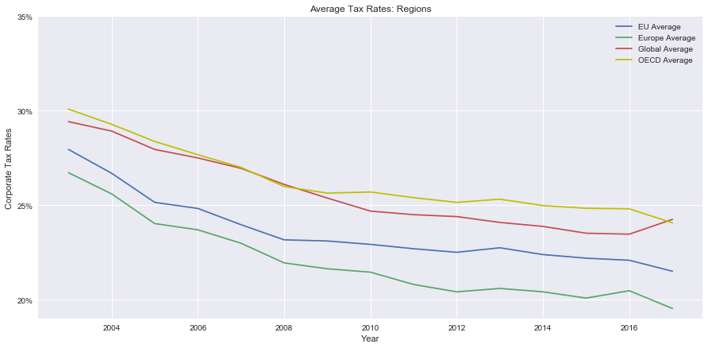

```python
plt.figure('Average Tax Rates: Regions')
plt.plot(year,region_averages['EU average'])           #Visualization for the overview of EU, European and world wide tax rates.
plt.plot(year,region_averages['Europe average'])
plt.plot(year,region_averages['Global average'])
plt.plot(year,region_averages['OECD average'], 'y-') #I like to use yellow to make a clearer distinction!
plt.xlabel('Year')
plt.ylabel('Corporate Tax Rates')
plt.yticks([20.0, 25.0, 30.0, 35.0], ['20%', '25%', '30%', '35%'])
plt.title('Average Tax Rates: Regions')
plt.legend(['EU Average', 'Europe Average', 'Global Average', 'OECD Average'])
plt.show()
```

### Tax Havens

The European Union has made an [official list](http://www.consilium.europa.eu/media/31945/st15429en17.pdf) of what they call 'non-cooperative jurisdictions for tax purposes'. At that time, there were seventeen tax jurisdictions on the list. However, there is [criticism](https://www.politico.eu/pro/eu-places-17-countries-on-tax-haven-blacklist-but-none-of-its-own/) as to why some of the EU member states such as Luxembourg, Ireland and the Netherlands are not on this list. These three countries were known for being favorable to reduce your global tax bill. To take a look at these three countries and their tax rates, see the following graph:

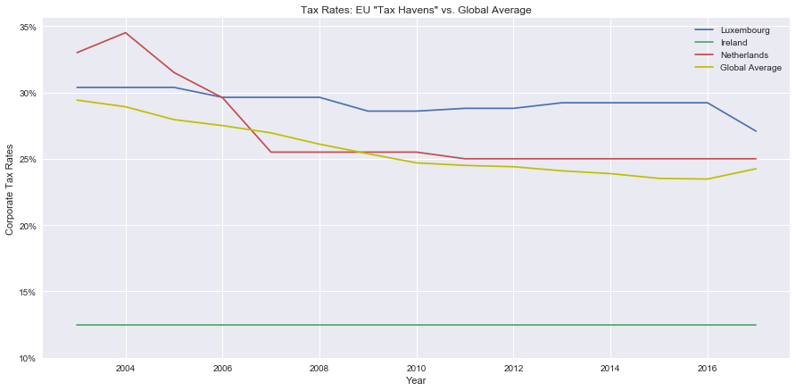

```python
plt.plot(year,countries['Luxembourg'])
plt.plot(year,countries['Ireland'])             #The 3 criticised countries and the global average.
plt.plot(year,countries['Netherlands'])
plt.plot(year,region_averages['Global average'], 'y-')
plt.xlabel('Year')
plt.ylabel('Corporate Tax Rates')
plt.yticks([10.0, 15.0, 20.0, 25.0, 30.0, 35.0], ['10%', '15%', '20%', '25%', '30%', '35%'])
plt.title('Tax Rates: EU "Tax Havens" vs. Global Average')
plt.legend(['Luxembourg','Ireland','Netherlands','Global Average'])
plt.show()
```

As we can see in the graph, the tax rate of Ireland is much lower (12.5%) than the other two countries in question and the global average. Many large companies are set up in Ireland, such as Google, Facebook and Apple. The country is definitely attractive for business mostly because of the low tax rates. Even when Apple was forced to pay a huge sum of cash, Ireland didn't [want](https://www.nbcnews.com/tech/apple/apple-agrees-pay-15-4-billion-back-taxes-ireland-even-n826701) it. Although the Netherlands and Luxembourg are known as tax havens, they are both above the global average. This goes to show that there are more factors that determine the tax bill than just the corporate tax rate.

Let's have a look at the two countries that were the big players in the two major tax scandals, LuxLeaks and the Panama Papers:

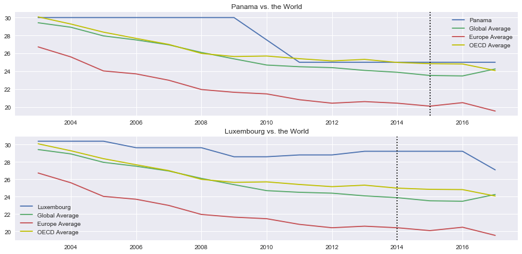

```python
fig = plt.figure()                                        #Subplotting to have two graphs together.
plt.subplot(2,1,1)                                        #Two rows of plots, one column (To stack them), first plot.
plt.plot(year,countries['Panama'])
plt.plot(year,region_averages['Global average'])
plt.plot(year,region_averages['Europe average'])
plt.plot(year,region_averages['OECD average'], 'y-')
plt.axvline(x=2015, color='k', linestyle=':')             #Dotted line to make the distinction better.
plt.title('Panama vs. the World')
plt.legend(['Panama', 'Global Average', 'Europe Average', 'OECD Average'])

plt.subplot(2,1,2)
plt.plot(year,countries['Luxembourg'])
plt.plot(year,region_averages['Global average'])
plt.plot(year,region_averages['Europe average'])
plt.plot(year,region_averages['OECD average'], 'y-')
plt.axvline(x=2014, color='k', linestyle=':')
plt.title('Luxembourg vs. the World')
plt.legend(['Luxembourg', 'Global Average', 'Europe Average', 'OECD Average'])
plt.show()
```

In the first graph we have the tax rates for Panama and a few other tax regions. The graph shows that Panama's corporate tax rate has been well above the average tax rates around the world. It has remained very stable, only seeing one drop from 30% to 25%. Even then, the country doesn't follow the same trend as much as the European Average. The dotted black line represents when the Panama Papers were published. After this happened, there has not been any noticable change in corporate tax rates in both the country or around the world.

The second graph shows the same plot, but then for Luxembourg. Again, the dotted line shows the time all the secret documents were uncovered and in this case that is the Luxleaks. Just like Panama, Luxembourg is far above the corporate tax rates of other regions. Luxembourg hasn't moved towards the global average like Panama did. It has remained fairly stable above it. These two graphs show that the tax havens don't attract firms using the corporate tax rate, if that were the case the opposite would be true: almost no business in these countries. They also show that after all these documents are available to the public, the countries don't seem to change their behavior in terms of the tax rate.

All the 'non-tax havens' also don't change their tax rate setting after these publications. What we do see is the downwards trend of corporate tax rates that I mentioned earlier, this 'Race to the bottom' could be caused by the existence of these tax havens. The downward trend could be to fight back against these tax havens attracting their firms to make their own country more attractive.

There must be other ways for tax jurisdictions to attract firms. Of course, there are many. Taxation isn't simply taking a share of the profits, there are many deductibles and exemptions that are available. It's all a matter of how these countries apply different sets of rules to their taxation. The image below shows how countries differ in dealing with dividends.

[figure not shown]

As you can see, most of these countries have an unique set of tax rates and credit or exemption of foreign dividends. There are even differences between treaty countries or non-treaty countries. And this is just a small part of determining the total tax burden. The tax havens that attract many firms use all these different rules to make it a very 'business friendly environment'. The government in Luxembourg was also involved in many talks with accounting firms to get the multinationals to their country. Here is a short video of what mechanisms were used by firms to reduce their worldwide tax bill:

```python
YouTubeVideo("DTB90Ulu_5E")
```

[video not shown]

### Conclusion

The past 15 years has shown that there is a downwards trend when it comes to corporate tax rates. Whether this is because of tax havens, tax competition or because of the economic crisis remains the question. That is beyond this short investigation of the two tax scandals and tax trends. I can definitely conclude that the corporate tax rate is not the main reason for being classified as a 'tax haven' and many other factors play a role.

To answer the question, the downwards trend in tax rate *might* be due to increased competition from tax havens. The tax rates after publication of the documents does not seem to be affected.

### Limitations

The intention of this assignment was to give a very basic insight of what global statutory corporate tax rates look like for the past 15 years and see if there are any changes due to Luxembourg and Panama paper being revealed as tax havens (And getting some practice with Python, of course). To really see the impact of the existence of these environments, a closer look would need to be taken at all the different kinds of methods and deductibles that countries use, rather than the tax rates.

Go back to the top ↑